# Planejamento fatorial completo com duplicata na área térmica

Andres Stiven Carreño Jerez

2026-05-26

# Construção Fatorial completo 2² con duplicata experimental

```r
library(FrF2)
dados1=data.frame(A = c(-1,-1,1,1,-1,-1,1,1),
                    B = c(-1,-1,-1,-1,1,1,1,1),
                  rep = c(1,2,1,2,1,2,1,2),
                    k = c(0.31,0.33,0.58,0.61,0.35,0.36,0.72,0.75))

dados1
```

| A | B | rep | k |
| --- | --- | --- | --- |
| -1 | -1 | 1 | 0.31 |
| -1 | -1 | 2 | 0.33 |
| 1 | -1 | 1 | 0.58 |
| 1 | -1 | 2 | 0.61 |
| -1 | 1 | 1 | 0.35 |
| -1 | 1 | 2 | 0.36 |
| 1 | 1 | 1 | 0.72 |
| 1 | 1 | 2 | 0.75 |

# Médias e desvios por condição

```r
condicoes=aggregate(k ~ A + B, data = dados1,
                       FUN = function(x) c(media = mean(x), dp = sd(x)))
cat("\n=== MÉDIA E DP POR CONDIÇÃO ===\n")
```

```
##
## === MÉDIA E DP POR CONDIÇÃO ===
```

```r
print(condicoes)
```

```
##    A  B     k.media        k.dp
## 1 -1 -1 0.320000000 0.014142136
## 2  1 -1 0.595000000 0.021213203
## 3 -1  1 0.355000000 0.007071068
## 4  1  1 0.735000000 0.021213203
```

# Calcular efeitos

```r
y=dados1$k
sA=dados1$A
sB=dados1$B
sAB=sA * sB

efecto <- function(s, y) sum(s * y) / (length(y)/2)

cat("\n=== EFEITOS ===\n")
```

```
##
## === EFEITOS ===
```

```r
cat(sprintf("Efeito A  (Grafite)   : %+.5f W/(m·K)\n", efecto(sA,  y)))
```

```
## Efeito A  (Grafite)   : +0.32750 W/(m·K)
```

```r
cat(sprintf("Efeito B  (Temperatura): %+.5f W/(m·K)\n", efecto(sB,  y)))
```

```
## Efeito B  (Temperatura): +0.08750 W/(m·K)
```

```r
cat(sprintf("Efeito AB              : %+.5f W/(m·K)\n", efecto(sAB, y)))
```

```
## Efeito AB              : +0.05250 W/(m·K)
```

# ANOVA

```r
dados1$A <- as.factor(dados1$A)
dados1$B <- as.factor(dados1$B)

modelo7 <- lm(k ~ A * B, data = dados1)

print(anova(modelo7))
```

```
## Analysis of Variance Table
##
## Response: k
##           Df   Sum Sq  Mean Sq F value    Pr(>F)
## A          1 0.214513 0.214513 746.130 1.068e-05 ***
## B          1 0.015313 0.015313  53.261  0.001874 **
## A:B        1 0.005512 0.005512  19.174  0.011886 *
## Residuals  4 0.001150 0.000288
## ---
## Signif. codes:  0 '***' 0.001 '**' 0.01 '*' 0.05 '.' 0.1 ' ' 1
```

```r
print(summary(modelo7))
```

```
##
## Call:
## lm.default(formula = k ~ A * B, data = dados1)
##
## Residuals:
##      1      2      3      4      5      6      7      8
## -0.010  0.010 -0.015  0.015 -0.005  0.005 -0.015  0.015
##
## Coefficients:
##             Estimate Std. Error t value Pr(>|t|)
## (Intercept)  0.32000    0.01199  26.690 1.17e-05 ***
## A1           0.27500    0.01696  16.219 8.46e-05 ***
## B1           0.03500    0.01696   2.064   0.1079
## A1:B1        0.10500    0.02398   4.379   0.0119 *
## ---
## Signif. codes:  0 '***' 0.001 '**' 0.01 '*' 0.05 '.' 0.1 ' ' 1
##
## Residual standard error: 0.01696 on 4 degrees of freedom
## Multiple R-squared:  0.9951, Adjusted R-squared:  0.9915
## F-statistic: 272.9 on 3 and 4 DF,  p-value: 4.427e-05
```

# Grafo Efe

```r
plano7=FrF2(nruns    = 4,nfactors = 2,factor.names = list(A = c(-1, 1),B = c(-1, 1)),randomize = FALSE
)
```

```
## creating full factorial with 4 runs ...
```

```r
# ✅ Agregar respuesta con add.response() — NO con $
k_medias=c(0.320, 0.595, 0.355, 0.735)
plano7=add.response(plano7, k_medias)

# Verificar que quedó bien
print(plano7)
```

```
##    A  B k_medias
## 1 -1 -1    0.320
## 2  1 -1    0.595
## 3 -1  1    0.355
## 4  1  1    0.735
## class=design, type= full factorial
```

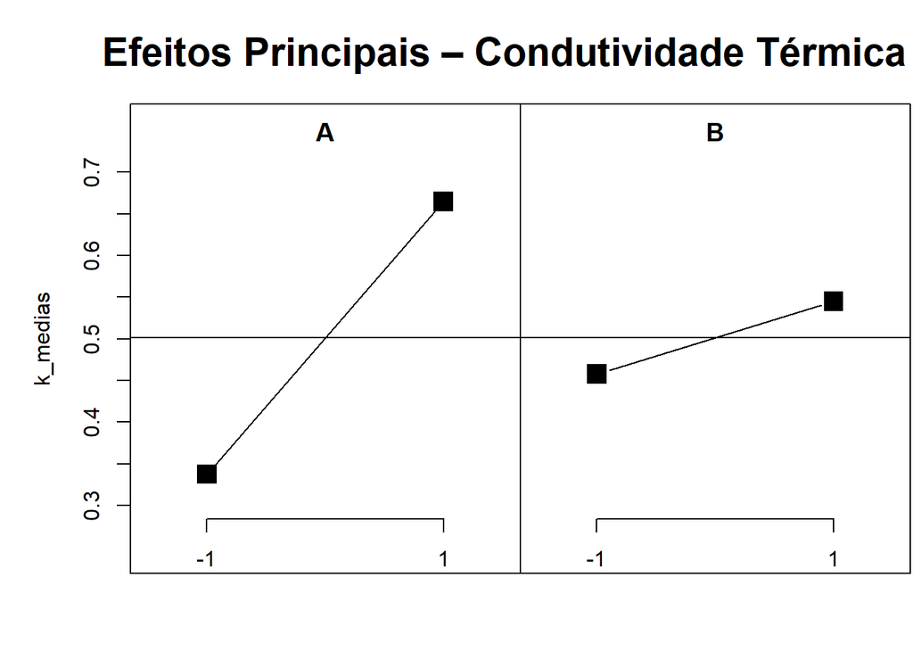

```r
# Gráfico de efectos principales
MEPlot(plano7,
       response = "k_medias",
       main     = "Efeitos Principais – Condutividade Térmica k")
```

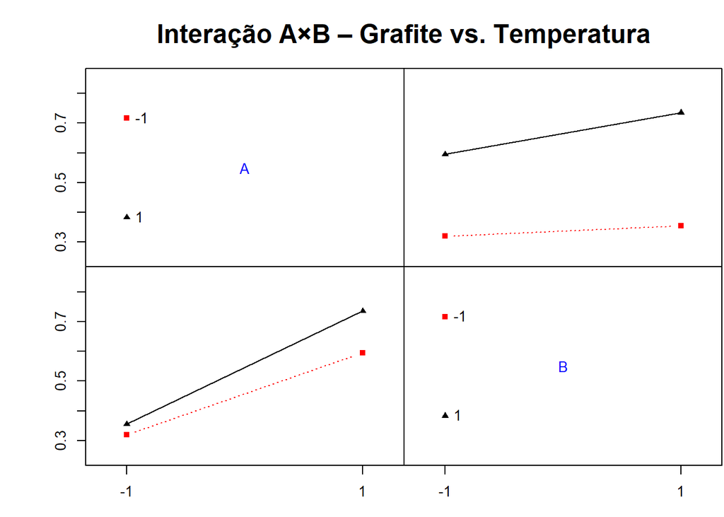

```r
# Gráfico de interacción
IAPlot(plano7,
       response = "k_medias",
       main     = "Interação A×B – Grafite vs. Temperatura")
```

# Grafo Efe

El factor más importante fue: ★ A – Teor de grafite expandido (efecto = +0,3275 W·m⁻¹·K⁻¹)

Su efecto POSITIVO indica que pasar del nivel bajo al nivel alto AUMENTA fuertemente la conductividad: - Nivel bajo = 5% de grafite expandido - Nivel alto = 15% de grafite expandido → Mayor concentración de grafite maximiza la conducción térmica del compósito.

═══════════════════════════════════════════════════════════ EFECTOS PRINCIPALES ═══════════════════════════════════════════════════════════ A (Teor grafite) : +0,3275 W·m⁻¹·K⁻¹ → DOMINANTE ★ B (Temp. prensagem) : +0,0875 W·m⁻¹·K⁻¹ → moderado A×B (interacción) : +0,0525 W·m⁻¹·K⁻¹ → significativa

═══════════════════════════════════════════════════════════ ANOVA – SIGNIFICANCIA ESTADÍSTICA ═══════════════════════════════════════════════════════════ Fuente F calculado F crítico(5%) Conclusión ────────────────────────────────────────────────── A 746,1 7,71 SIGNIFICATIVO ✅ B 53,3 7,71 SIGNIFICATIVO ✅ A×B 19,2 7,71 SIGNIFICATIVO ✅ ────────────────────────────────────────────────── Los TRES efectos son estadísticamente significativos.

═══════════════════════════════════════════════════════════ INTERACCIÓN A×B — SINERGIA ENTRE FACTORES ═══════════════════════════════════════════════════════════ Con bajo grafite (5%): B sube k apenas +0,035 W·m⁻¹·K⁻¹

Con alto grafite (15%): B sube k en +0,140 W·m⁻¹·K⁻¹

→ La temperatura de prensagem ayuda MUCHO MÁS cuando hay alta concentración de grafite. → Los dos factores actúan en SINERGIA — juntos producen un efecto mayor que la suma individual.

═══════════════════════════════════════════════════════════ REPETIBILIDAD DEL EXPERIMENTO ═══════════════════════════════════════════════════════════ Condición k̄ (W·m⁻¹·K⁻¹) DP ───────────────────────────────────────── A=5%, T=170°C 0,320 0,0141 A=15%, T=170°C 0,595 0,0212 A=5%, T=190°C 0,355 0,0071 A=15%, T=190°C 0,735 0,0212 ───────────────────────────────────────── Todos los DP son pequeños → alta repetibilidad ✅ El experimento es confiable y reproducible.

═══════════════════════════════════════════════════════════ MEJOR CONDICIÓN EXPERIMENTAL ═══════════════════════════════════════════════════════════ Para MAXIMIZAR la conductividad térmica:

→ ENSAYO condición 4: - Teor de grafite : 15% (nivel alto) - Temp. de prensagem : 190°C (nivel alto) - k média : 0,735 W·m⁻¹·K⁻¹ ← mayor valor - DP : 0,021 ← repetible ✅ - CV : 2,9% ← excelente ✅

Esta condición aprovecha la SINERGIA A×B: el grafite forma redes conductoras (percolación) y la alta temperatura mejora el contacto entre partículas durante la prensagem.